# Random Forests for Question 2

Mary Fisher

3/16/2020

Research Question 2: What is the relationship between biodiversity and habitat conditions?

The response variables for which we were able to find “good enough” correlations with our available predictors are: fish total biomass, invertebrate total biomass and diversity, algae total biomass.

# Prepare Data

Read in data. grab only the columns of interest.

```r
mydat <- read.csv(here::here("data","biomass_prediction_data_waterchem_bysite_complete.csv")) %>%
  clean_names()
mydat <- mydat[,-c(2,15:20)]
colnames(mydat)
```

```
##  [1] "year"                 "site"                 "fish_total_biomass"
##  [4] "fish_diversity"       "invert_total_biomass" "invert_diversity"
##  [7] "algae_total_biomass"  "algae_diversity"      "kelp_total_biomass"
## [10] "summer_mean_temp"     "summer_var_temp"      "winter_mean_temp"
## [13] "winter_var_temp"      "mean_ammonia"         "mean_no2_no3"
## [16] "mean_po4"             "mean_poc"             "mean_pon"
## [19] "mean_tchl"
```

## Multicollinearity

I know from script `05_linear_models_timeseries_total_biomass` that summer and winter temperatures are correlated; since kelp is a cold-water species, we’ll stick with summer temperature only. I’ll rely on variable selection to remove either mean or variance in temperature, which are also correlated with each other. Particulate organic carbon (`poc`) is highly correlated with particulate organic nitrogen and mean total chlorophyll. I’ll remove particulate organic carbon.

```r
mydat <- mydat %>%
  dplyr::select(-winter_mean_temp,-winter_var_temp,-mean_poc)
colnames(mydat)
```

```
##  [1] "year"                 "site"                 "fish_total_biomass"
##  [4] "fish_diversity"       "invert_total_biomass" "invert_diversity"
##  [7] "algae_total_biomass"  "algae_diversity"      "kelp_total_biomass"
## [10] "summer_mean_temp"     "summer_var_temp"      "mean_ammonia"
## [13] "mean_no2_no3"         "mean_po4"             "mean_pon"
## [16] "mean_tchl"
```

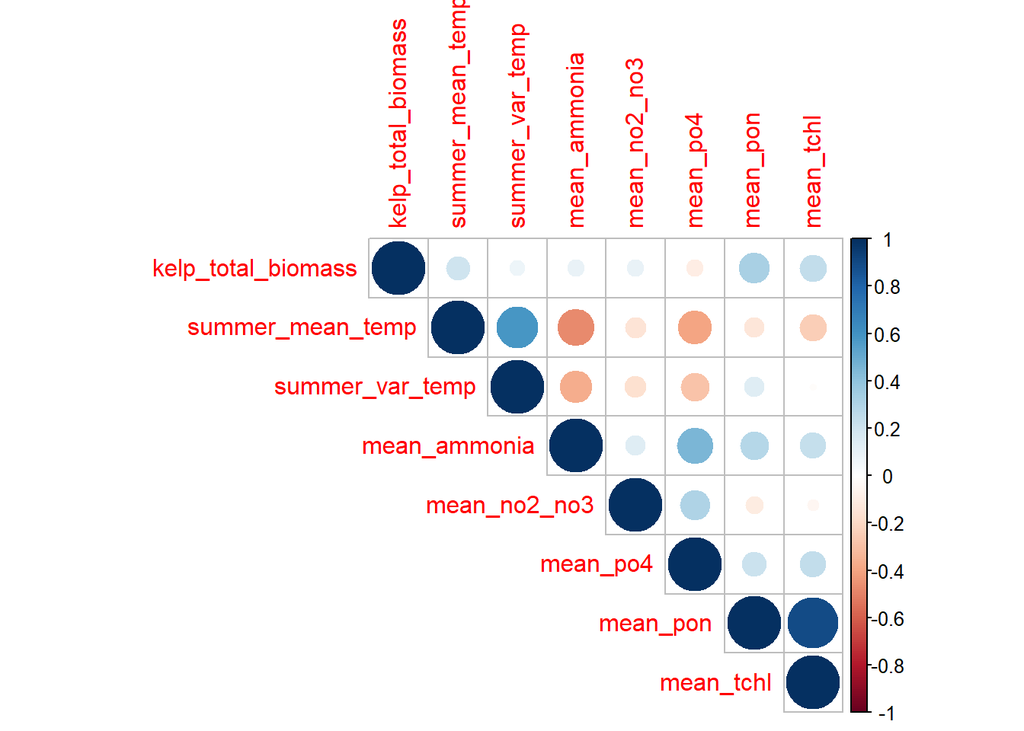

## Transform variables

According to the script [04_explore_predictors](https://github.com/mfisher5/504_BiodivSB/tree/master/scripts), many of the predictor variables are not normally distributed.

```r
mydat.t <- mydat %>%
  mutate(summer_var_temp = log(summer_var_temp),
         mean_pon= log(mean_pon),
         mean_tchl= log(mean_tchl),
         kelp_total_biomass=(kelp_total_biomass)^(1/3),
         invert_total_biomass=(invert_total_biomass)^(0.125),
         invert_diversity=(invert_diversity)^(-2),
         fish_total_biomass=(fish_total_biomass)^0.06)
colnames(mydat.t)
```

```
##  [1] "year"                 "site"                 "fish_total_biomass"
##  [4] "fish_diversity"       "invert_total_biomass" "invert_diversity"
##  [7] "algae_total_biomass"  "algae_diversity"      "kelp_total_biomass"
## [10] "summer_mean_temp"     "summer_var_temp"      "mean_ammonia"
## [13] "mean_no2_no3"         "mean_po4"             "mean_pon"
## [16] "mean_tchl"
```

# Random Forests

## Invertebrate Biomass

```r
rfdat <- mydat.t %>%
  dplyr::select(c(2,5,9:16))
colnames(rfdat)
```

```
##  [1] "site"                 "invert_total_biomass" "kelp_total_biomass"
##  [4] "summer_mean_temp"     "summer_var_temp"      "mean_ammonia"
##  [7] "mean_no2_no3"         "mean_po4"             "mean_pon"
## [10] "mean_tchl"
```

### Optimize Parameters

First, create the grid of parameter combinations.

```r
hyper_grid <- expand.grid(
  mtry       = seq(2, 8, by = 2),
  node_size  = seq(3, 7, by = 1),
  sampe_size = c(.60, .65, .70, .80),
  OOB_RMSE   = 0
)
```

Then iterate through grid and find which combination of parameters provides the lowest root mean squared error (RMSE). This will be the parameter combination at the top of the data frame, output below.

```r
set.seed(100)

for(i in 1:nrow(hyper_grid)) {

  # train model
  model <- ranger(
    formula         = invert_total_biomass ~ .,
    data            = rfdat,
    num.trees       = 500,
    mtry            = hyper_grid$mtry[i],
    min.node.size   = hyper_grid$node_size[i],
    sample.fraction = hyper_grid$sampe_size[i],
    seed            = 123
  )

  # add OOB error to grid
  hyper_grid$OOB_RMSE[i] <- sqrt(model$prediction.error)
}

hyper_grid %>%
  dplyr::arrange(OOB_RMSE) %>%
  head(10)
```

```
##    mtry node_size sampe_size  OOB_RMSE
## 1     8         3       0.80 0.1979127
## 2     8         5       0.80 0.1979495
## 3     8         4       0.80 0.1985605
## 4     8         6       0.80 0.1990989
## 5     8         7       0.80 0.1993429
## 6     8         5       0.65 0.2042199
## 7     8         4       0.65 0.2044806
## 8     8         6       0.65 0.2052829
## 9     8         3       0.65 0.2059310
## 10    8         7       0.65 0.2065249
```

### Run Model

Rerun the optimal model (by manually entering the parameters identified above) a bunch of times to get a distribution of Residual MSE.

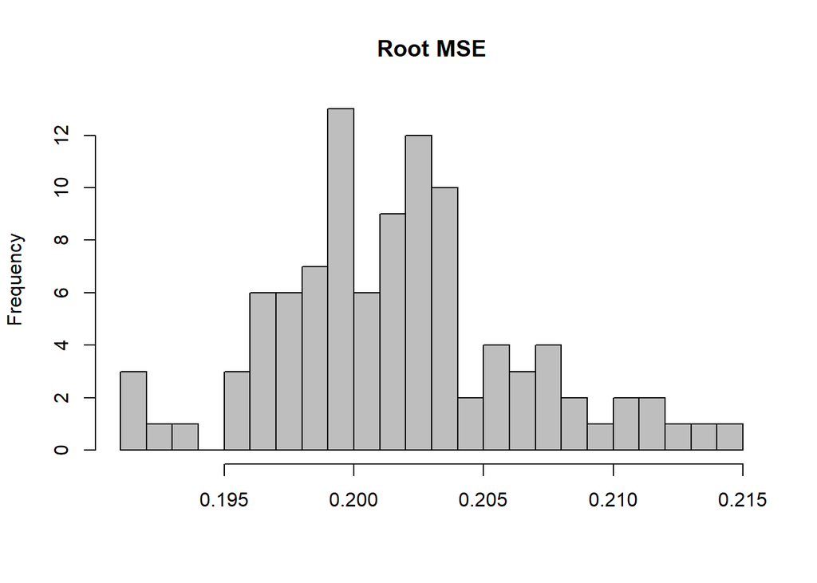

```r
OOB_RMSE <- vector(mode = "numeric", length = 100)

for(i in seq_along(OOB_RMSE)) {

  optimal_ranger <- ranger(
    formula         = invert_total_biomass ~ .,
    data            = rfdat,
    num.trees       = 500,
    mtry            = 8,
    min.node.size   = 3,
    sample.fraction = .8,
    importance      = 'impurity'
  )

  OOB_RMSE[i] <- sqrt(optimal_ranger$prediction.error)
}

hist(OOB_RMSE, breaks = 20, main="Root MSE", xlab="",col="grey")
```

Now get the importance of the predictors in this optimal model

[figure not shown]

```r
set.seed(100)
n <- dim(rfdat)[1]
trainrows <- sample(1:n, round(0.7*n))
testrows <- seq(1:n)[which(!(seq(1:n) %in% trainrows))]
rfdat.train <- rfdat %>%
  dplyr::slice(trainrows)
rfdat.test <- rfdat %>%
  dplyr::slice(testrows)

final_model <- ranger(
    formula   = invert_total_biomass ~ .,
    data      = rfdat.train,
    num.trees = 500,
    mtry      = 4,
    min.node.size = 6,
    importance      = 'impurity'
)
```

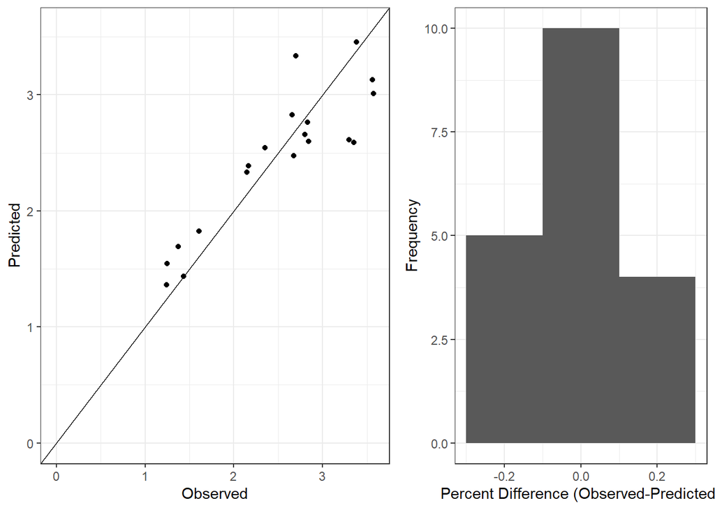

## Invertebrate Diversity

```r
rfdat <- mydat.t %>%
  dplyr::select(c(2,6,9:16))
colnames(rfdat)
```

```
##  [1] "site"               "invert_diversity"   "kelp_total_biomass"
##  [4] "summer_mean_temp"   "summer_var_temp"    "mean_ammonia"
##  [7] "mean_no2_no3"       "mean_po4"           "mean_pon"
## [10] "mean_tchl"
```

### Optimize Parameters

First, create the grid of parameter combinations.

```r
hyper_grid <- expand.grid(
  mtry       = seq(2, 8, by = 2),
  node_size  = seq(3, 7, by = 1),
  sampe_size = c(.60, .65, .70, .80),
  OOB_RMSE   = 0
)
```

Then iterate through grid and find which combination of parameters provides the lowest root mean squared error (RMSE). This will be the parameter combination at the top of the data frame, output below.

```r
set.seed(100)

for(i in 1:nrow(hyper_grid)) {

  # train model
  model <- ranger(
    formula         = invert_diversity ~ .,
    data            = rfdat,
    num.trees       = 500,
    mtry            = hyper_grid$mtry[i],
    min.node.size   = hyper_grid$node_size[i],
    sample.fraction = hyper_grid$sampe_size[i],
    seed            = 123
  )

  # add OOB error to grid
  hyper_grid$OOB_RMSE[i] <- sqrt(model$prediction.error)
}

hyper_grid %>%
  dplyr::arrange(OOB_RMSE) %>%
  head(10)
```

```
##    mtry node_size sampe_size  OOB_RMSE
## 1     4         3        0.6 0.1526008
## 2     4         4        0.7 0.1528900
## 3     4         5        0.7 0.1531584
## 4     4         4        0.6 0.1532834
## 5     4         6        0.7 0.1534691
## 6     4         3        0.7 0.1534931
## 7     6         3        0.7 0.1539383
## 8     4         7        0.7 0.1540483
## 9     4         5        0.8 0.1541660
## 10    4         5        0.6 0.1541747
```

### Run Model

Rerun the optimal model (by manually entering the parameters identified above) a bunch of times to get a distribution of Residual MSE.

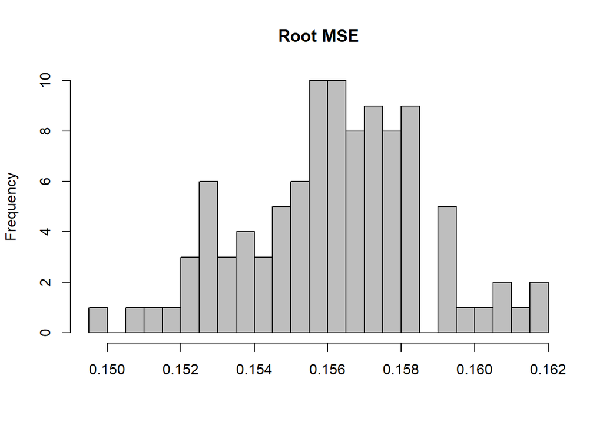

```r
OOB_RMSE <- vector(mode = "numeric", length = 100)

for(i in seq_along(OOB_RMSE)) {

  optimal_ranger <- ranger(
    formula         = invert_diversity ~ .,
    data            = rfdat,
    num.trees       = 500,
    mtry            = 4,
    min.node.size   = 3,
    sample.fraction = .6,
    importance      = 'impurity'
  )

  OOB_RMSE[i] <- sqrt(optimal_ranger$prediction.error)
}

hist(OOB_RMSE, breaks = 20, main="Root MSE", xlab="",col="grey")
```

Now get the importance of the predictors in this optimal model

[figure not shown]

```r
set.seed(100)
n <- dim(rfdat)[1]
trainrows <- sample(1:n, round(0.7*n))
testrows <- seq(1:n)[which(!(seq(1:n) %in% trainrows))]
rfdat.train <- rfdat %>%
  dplyr::slice(trainrows)
rfdat.test <- rfdat %>%
  dplyr::slice(testrows)

final_model <- ranger(
    formula   = invert_diversity ~ .,
    data      = rfdat.train,
    num.trees = 500,
    mtry      = 4,
    min.node.size = 3,
    importance      = 'impurity'
)
```

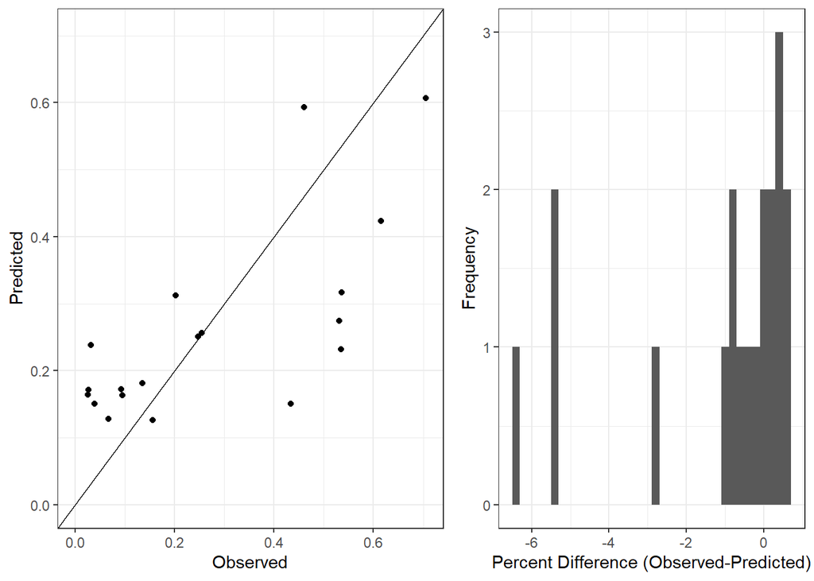

## Fish Total Biomass

```r
rfdat <- mydat.t %>%
  dplyr::select(c(2,3,9:16))
colnames(rfdat)
```

```
##  [1] "site"               "fish_total_biomass" "kelp_total_biomass"
##  [4] "summer_mean_temp"   "summer_var_temp"    "mean_ammonia"
##  [7] "mean_no2_no3"       "mean_po4"           "mean_pon"
## [10] "mean_tchl"
```

### Optimize Parameters

First, create the grid of parameter combinations.

```r
hyper_grid <- expand.grid(
  mtry       = seq(2, 8, by = 2),
  node_size  = seq(3, 7, by = 1),
  sampe_size = c(.60, .65, .70, .80),
  OOB_RMSE   = 0
)
```

Then iterate through grid and find which combination of parameters provides the lowest root mean squared error (RMSE). This will be the parameter combination at the top of the data frame, output below.

```r
set.seed(100)

for(i in 1:nrow(hyper_grid)) {

  # train model
  model <- ranger(
    formula         = fish_total_biomass ~ .,
    data            = rfdat,
    num.trees       = 500,
    mtry            = hyper_grid$mtry[i],
    min.node.size   = hyper_grid$node_size[i],
    sample.fraction = hyper_grid$sampe_size[i],
    seed            = 123
  )

  # add OOB error to grid
  hyper_grid$OOB_RMSE[i] <- sqrt(model$prediction.error)
}

hyper_grid %>%
  dplyr::arrange(OOB_RMSE) %>%
  head(10)
```

```
##    mtry node_size sampe_size   OOB_RMSE
## 1     8         7       0.80 0.07347732
## 2     8         7       0.65 0.07359768
## 3     8         6       0.80 0.07368161
## 4     8         6       0.65 0.07372951
## 5     8         5       0.65 0.07413884
## 6     8         7       0.70 0.07417904
## 7     8         5       0.70 0.07418507
## 8     6         6       0.65 0.07438888
## 9     8         4       0.70 0.07442077
## 10    6         7       0.65 0.07443523
```

### Run Model

Rerun the optimal model (by manually entering the parameters identified above) a bunch of times to get a distribution of Residual MSE.

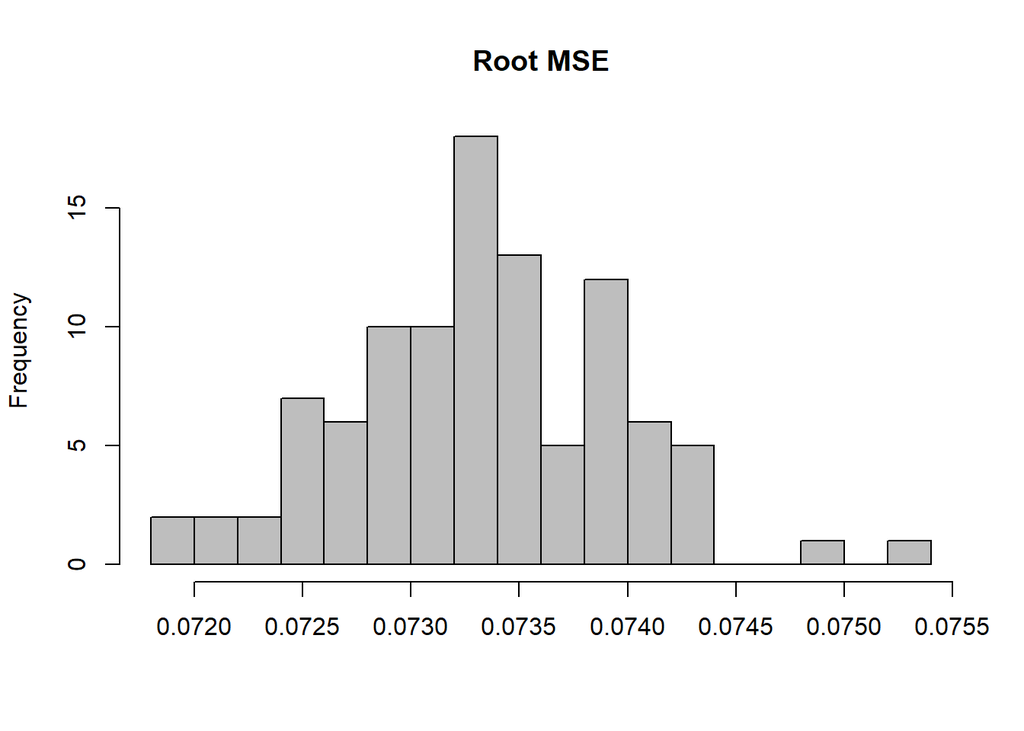

```r
OOB_RMSE <- vector(mode = "numeric", length = 100)

for(i in seq_along(OOB_RMSE)) {

  optimal_ranger <- ranger(
    formula         = fish_total_biomass ~ .,
    data            = rfdat,
    num.trees       = 500,
    mtry            = 8,
    min.node.size   = 7,
    sample.fraction = .8,
    importance      = 'impurity'
  )

  OOB_RMSE[i] <- sqrt(optimal_ranger$prediction.error)
}

hist(OOB_RMSE, breaks = 20, main="Root MSE", xlab="",col="grey")
```

Now get the importance of the predictors in this optimal model

[figure not shown]

```r
set.seed(100)
n <- dim(rfdat)[1]
trainrows <- sample(1:n, round(0.7*n))
testrows <- seq(1:n)[which(!(seq(1:n) %in% trainrows))]
rfdat.train <- rfdat %>%
  dplyr::slice(trainrows)
rfdat.test <- rfdat %>%
  dplyr::slice(testrows)

final_model <- ranger(
    formula   = fish_total_biomass ~ .,
    data      = rfdat.train,
    num.trees = 500,
    mtry      = 4,
    min.node.size = 3,
    importance      = 'impurity'
)
```

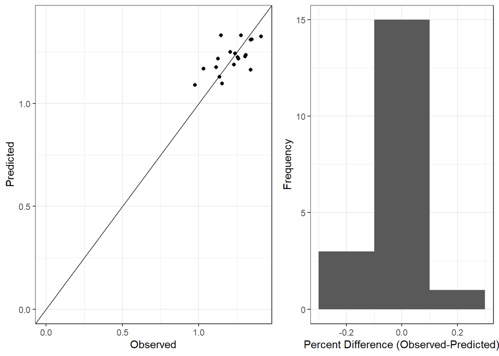